# Progress Memo

## Target variable analysis

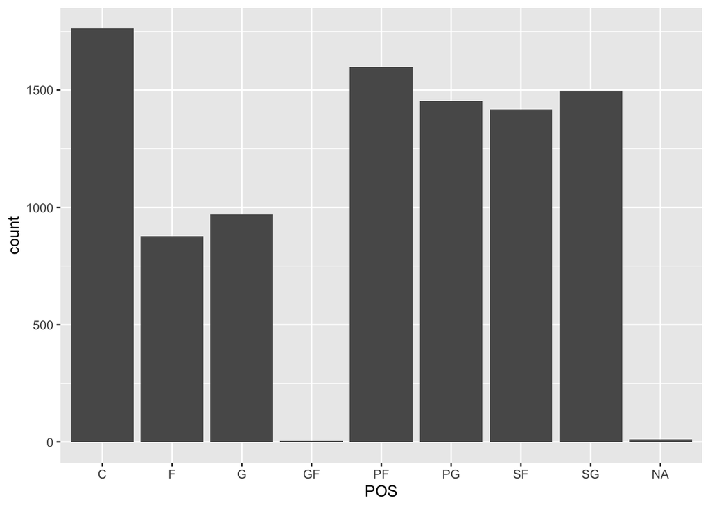

The target variable seems to be imbalanced for certain levels. It is heavily imbalanced for the level of GF. However, because of its low count, it may be beneficial to filter out the small group of players who are GF (guards/fowards).

## Potential data issues

When thinking about potential issues, the issue surrounding the imbalance of certain positions may arise. It can be difficult to fix this, as certain positions are rather specialized and dependent on other factors like player measurements. To handle this, I will use stratified sampling during the model building process to ensure that the imbalance is reflected in the training process.